# Distance Between EV Charging Stations

Torin Rose

2023-05-18

# Outline

The goal of this case study is to calculate the average distance between public charging stations for electric vehicles (EVs) within the United States, grouped by state and year.

## Loading our library and data and displaying the structure of the raw data

```r
library(tidyverse)
library(lubridate)
library(compiler)
library(corrgram)
library(ggtext)

df <- read.csv('D:/GoogleDataAnalyticsCertificate/8.CapstoneProject/ev_fuel_stations_5.18.2023.csv')

str(df)
```

```
## 'data.frame':    57679 obs. of  72 variables:
##  $ Fuel.Type.Code                         : chr  "ELEC" "ELEC" "ELEC" "ELEC" ...
##  $ Station.Name                           : chr  "Los Angeles Convention Center" "California Air Resources Board" "Scripps Green Hospital" "Galpin Motors" ...
##  $ Street.Address                         : chr  "1201 S Figueroa St" "9530 Telstar Ave" "10666 N Torrey Pines Rd" "15421 Roscoe Blvd" ...
##  $ Intersection.Directions                : chr  "West hall and South hall" "" "Patient Parking Structure, level G" "" ...
##  $ City                                   : chr  "Los Angeles" "El Monte" "La Jolla" "Sepulveda" ...
##  $ State                                  : chr  "CA" "CA" "CA" "CA" ...
##  $ ZIP                                    : chr  "90015" "91731" "92037" "91343" ...
##  $ Plus4                                  : logi  NA NA NA NA NA NA ...
##  $ Station.Phone                          : chr  "213-741-1151" "626-575-6800" "" "800-256-6219" ...
##  $ Status.Code                            : chr  "E" "E" "E" "E" ...
##  $ Expected.Date                          : chr  "" "" "" "" ...
##  $ Groups.With.Access.Code                : chr  "Public" "Public" "Public" "Public - Call ahead" ...
##  $ Access.Days.Time                       : chr  "5:30am-9pm; pay lot" "24 hours daily" "24 hours daily" "Dealership business hours" ...
##  $ Cards.Accepted                         : chr  "" "" "" "" ...
```

[output cut: 58 more lines]

Because of the criteria I used when I downloaded the data set from https://developer.nrel.gov/docs/transportation/alt-fuel-stations-v1/all/, many of these columns are empty. The full data set includes many different forms of alternative fuel stations, however I filtered for only electric charging stations in the United States. I also opted to download a static data set to work with instead of utilizing the API of the website. This was more for my own peace of mind, as this is a beginner project for me and I wanted to simplify where I saw fit.

## Narrowing down our variables to accomplish our goal

Since we’re only concerned with location of these EV charging stations and when they became operational, we’ll create a new data frame containing only the geographical data and the date they were opened. I used broad strokes for state grouping with the State column and will use the Latitude and Longitude columns to calculate distances. From there, I also picked (and converted to Dates) the Open Date column to know when the charging station became available for use and the Date Last Confirmed column to filter out stations that are potentially out of use. Also filtered out stations that are planned to be operational in the future using the Expected Date column (and had to include is.na() for the many rows that the Expected Date column is empty).

```r
charging_stations_df <- df %>%
  filter(ymd(Expected.Date)<=today() | is.na(ymd(Expected.Date))) %>%
  select(State, Latitude, Longitude, Date.Last.Confirmed, Open.Date) %>%
  mutate(Date.Last.Confirmed = ymd(Date.Last.Confirmed), Open.Date = ymd(Open.Date))

str(charging_stations_df)
```

```
## 'data.frame':    57657 obs. of  5 variables:
##  $ State              : chr  "CA" "CA" "CA" "CA" ...
##  $ Latitude           : num  34 34.1 32.9 34.2 33.9 ...
##  $ Longitude          : num  -118 -118 -117 -118 -117 ...
##  $ Date.Last.Confirmed: Date, format: "2023-01-10" "2022-09-14" ...
##  $ Open.Date          : Date, format: "1995-08-30" "1996-10-15" ...
```

### Cleaning the data

Now lets check if all our rows are complete and useful:

```r
charging_stations_df %>%
  filter(State == "" | is.na(Date.Last.Confirmed) | is.na(Open.Date))
```

```
##     State Latitude  Longitude Date.Last.Confirmed  Open.Date
## 1      MS 34.96163  -89.98559          2020-06-09       <NA>
## 2      CA 37.60235 -122.37068          2021-08-04       <NA>
## 3      MA 41.25825  -70.06310          2021-10-12       <NA>
## 4      FL 26.52756  -80.06324          2023-01-10       <NA>
## 5      FL 26.52581  -80.06305          2023-01-10       <NA>
## 6      FL 26.53013  -80.04768          2022-07-12       <NA>
## 7      VA 37.04455  -76.38059          2021-10-12       <NA>
## 8      NC 35.75362  -78.73950          2022-01-10       <NA>
## 9      MN 44.88052  -93.08064          2023-05-03       <NA>
## 10     CA 37.79198 -122.40972          2021-10-12       <NA>
## 11     CA 38.25146 -122.06981          2021-07-14       <NA>
## 12     FL 26.52833  -80.06111          2023-02-13       <NA>
## 13     MA 42.19704  -71.18526          2021-10-12       <NA>
## 14     CA 33.20738 -117.38785          2021-12-09       <NA>
```

[output cut: 91 more lines]

Looks like we’ll need to drop some rows with incomplete observations, first changing the empty states to NA so they’re included in our drop. We’ll do the same for Puerto Rico (state code PR) and a few data points that were included from India and Canada for some reason (state code KA, ON, respectively). There is probably a more elegant way to write this code, but it is quick and easy.

```r
start_difference <- nrow(charging_stations_df)

charging_stations_df <- charging_stations_df %>%
  mutate(State = na_if(State, "")) %>%
  mutate(State = na_if(State, "PR")) %>%
  mutate(State = na_if(State, "ON")) %>%
  mutate(State = na_if(State, "KA")) %>%
  drop_na()

end_difference <- nrow(charging_stations_df)
difference <- as.character(start_difference - end_difference)
print(paste("Stations removed: ", difference, sep=""))
```

```
## [1] "Stations removed: 162"
```

```r
print(paste("Oldest station confirmation: ", min(year(charging_stations_df$Date.Last.Confirmed))))
```

```
## [1] "Oldest station confirmation:  2019"
```

```r
# Found a station in the TX set that belongs in MS
row_to_change <- charging_stations_df %>%
  filter(Date.Last.Confirmed==ymd(20230517) & Open.Date==ymd(20221215) & State=="TX" & Latitude>34)

row_to_change$State = "MS"
charging_stations_df <- rows_update(charging_stations_df, row_to_change, by="Latitude")
```

Since the data represents a current snapshot of the stations in operation, there is not much insight into the timeline of stations needing to be repaired/out of commission. With this in mind, and the farthest back a station was confirmed only being four years ago, we will treat each station we have data on as open and available to the public.

## Our distance formula

To calculate the distance between our charging stations, we’ll be using a version of the Haversine formula, which utilizes trigonometry and the radius of a sphere to calculate the distance between two points on the surface of that sphere. The formula we’re using was obtained from http://powerappsguide.com/blog/post/formulas-calculate-the-distance-between-2-points-longitude-latitude and assuming a constant radius of Earth of 3958.8 miles. However, since the radius of our planet is not constant and we are assuming that we are travelling “as the crow flies”, the distances calculated will only be an approximation. That being said, this case study is more concerned with general distance between stations and less about the actual road route that is taken.

```r
distance <- function(latA, longA, latB, longB){
  radius <- 3958.8
  pi_radians <- pi/180

  (2 * radius) * asin(sqrt(0.5 - cos((latA - latB) * pi_radians)/2 + cos(latB * pi_radians) * cos(latA * pi_radians) * (1 - cos((longA - longB) * pi_radians))/2))
}

distance_compiled <- cmpfun(distance)
```

## Analysis

Now we can begin the analysis of our data. First, we’ll separate our stations by state, and then year. Then, going station by station, we’ll calculate the distance to every other station in that state (for the time being disregarding stations that are geographically near but across state lines). This will give us a state average for the distance between stations by year. We’re interested in how this number changes over time, and will later compare it to the average range of EV’s for that model year, inclusive of previous model years.

```r
state_abbr <- unique(charging_stations_df$State)
states_test <- c("ID")
for(states in states_test){
  dummy_df_name <- paste(states, "_analysis", sep="")
  station_by_state_and_year <- matrix(nrow=0, ncol=5)
  colnames(station_by_state_and_year) <- c("year","total_num_of_stations","new_stations_added","average_distance_mi","maximum_distance_mi")
  station_by_state <- charging_stations_df %>%
    filter(State == states)
  distances <- c()
  year_range <- (min(year(station_by_state$Open.Date)):2023)
  for(i_year in year_range){
    # Used to assign the distance vector each year to a separate variable for analysis
    dummy_year <- paste(states, "_", i_year, "_distances", sep="")

    station_count <- station_by_state %>%
      filter(year(Open.Date)<=i_year) %>%
      nrow()

    # Skipping iteration if there is only one station available
    if(station_count==1 & nrow(station_by_state_and_year)==0){
      station_by_state_and_year <- rbind(station_by_state_and_year, c(as.double(i_year), as.double(station_count), as.double(1), NA, NA))
      assign(dummy_year, distances)
    } else if(station_count==1){
      station_by_state_and_year <- rbind(station_by_state_and_year, c(as.double(i_year), as.double(station_count), as.double(0), NA, NA))
      assign(dummy_year, distances)
    } else {
      old_stations <- station_by_state %>%
        filter(year(Open.Date)<i_year)
      old_count <- nrow(old_stations)

      new_stations <- station_by_state %>%
        filter(year(Open.Date)==i_year)
      new_count <- nrow(new_stations)

      # Implementing our distance function by year, by station

      # If only one new station, skip the calculation loop within the new station data frame
      # Else (if) there are both old and new stations, calculate distances between all old stations and
      # all new stations as well as the distances between all new stations within the new station data frame.
      if(new_count==1){
        for(start_row in (1:old_count)){
            distances <- c(distances, distance_compiled(old_stations[start_row, "Latitude"], old_stations[start_row, "Longitude"], new_stations[1, "Latitude"], new_stations[1, "Longitude"]))
        }
      } else if(new_count>1){
        start_range <- (1:new_count-1)
        for(start_row in (start_range)){
          calc_range <- ((start_row+1):new_count)
          for(calc_row in (calc_range)){
            distances <- c(distances, distance_compiled(new_stations[start_row, "Latitude"], new_stations[start_row, "Longitude"], new_stations[calc_row, "Latitude"], new_stations[calc_row, "Longitude"]))
          }
        }
        # Accounting for multiple stations being added on the first year, thus having an old_count of zero
         if(old_count>0){
          for(start_row in (1:old_count)){
            for(calc_row in (1:new_count)){
              distances <- c(distances, distance_compiled(old_stations[start_row, "Latitude"], old_stations[start_row, "Longitude"], new_stations[calc_row, "Latitude"], new_stations[calc_row, "Longitude"]))
            }
          }
        }
      }

      station_by_state_and_year <- rbind(station_by_state_and_year, c(as.double(i_year), as.double(station_count), as.double(nrow(new_stations)), mean(distances), max(distances)))
      assign(dummy_year, distances)
    }
  }

  assign(dummy_df_name, station_by_state_and_year)
}
```

### Analysis Sidenote

This code has gone through a couple iterations to land here. I quickly found that, due to the sheer number of distance calculations required (both to compute and store) for states with a large number of stations (through trial and error and manually checking, I found this number to be a function of the total number of stations, N: $\sum_{i=1}^{N-1} i$) coupled with the `mean` calculation to be done on a vector of that size, this code took a very long time to run. As in I left my computer on for two days for California and only made it to 2021. I had to hard stop the running of it multiple times, rework the code, optimize as much as I could, and attempt to run it again. This led me to run this code chunk per state (set to “ID” for reproducibility) as opposed to iterating over the list of all states. At this point, I considered just making this chunk its own function and compiling that function to see if it improves performance, but have yet to implement this change, partly due to losing quite a bit of steam with all the tinkering. Regardless, until I come up with a better way to do this or upgrade my computing power, I am limited to results for states with a total station count of less than 1500, which is rather unfortunate.

For now, I only have the computation done for IA, ID, VT, and WA, which was the state that gave me a more realized upper limit. WA has a total of 1935 stations, which translates to 1,871,145 unique distance calculations across a 16 year range, with `mean` and `max` calculations done for each year. This alone took somewhere around 3-4 hours. I plan to perform more runs on the states with lower station counts to get as many sets of results as I can, but I am most interested in including the entire United States, so I am publishing this document in the current state in the hope of getting feedback and any help that can be offered!

Currently, I have most individual state analysis’ done, minus the few listed below without a complete date. For the time being, I am only focusing on Texas, and will perhaps revisit this project for other states in the future.

### Large sets:

- Texas – 2817 stations, 3966336 calculations. *Completed 2023.06.04*
- Colorado – 1919 stations, 1840321 calculations. *Completed 2023.06.05*
- Florida – 3077 stations, 4732426 calculations. *Completed 2023.06.06*
- Georgia – 1750 stations, 1530375 calculations. *Completed 2023.06.05*
- Massachusetts – 2659 stations, 3533811 calculations.
- New York – 3708 stations, 6872778 calculations.
- California – **15528** stations, **120551628** calculations.

## Continuing with smaller sets

When uploaded to Github, I commented this code out since it takes about 4 hours to run and I already have the calculations done and saved onto my local machine.

```r
# upper_limit_states_df <- charging_stations_df %>%
#   group_by(State) %>%
#   summarize(count = n()) %>%
#   filter(count<=1500)
#
# upper_limit_states <- unique(upper_limit_states_df$State)
#
# for(states in upper_limit_states){
#   dummy_df_name <- paste(states, "_analysis", sep="")
#   station_by_state_and_year <- matrix(nrow=0, ncol=5)
#   colnames(station_by_state_and_year) <- c("year","total_num_of_stations","new_stations_added","average_distance_mi","maximum_distance_mi")
#   station_by_state <- charging_stations_df %>%
#     filter(State == states)
#   distances <- c()
#   year_range <- (min(year(station_by_state$Open.Date)):2023)
#   for(i_year in year_range){
#     station_count <- station_by_state %>%
#       filter(year(Open.Date)<=i_year) %>%
#       nrow()
#
#     # Skipping iteration if there is only one station available
#     if(station_count==1 & nrow(station_by_state_and_year)==0){
#       station_by_state_and_year <- rbind(station_by_state_and_year, c(as.double(i_year), as.double(station_count), as.double(1), NA, NA))
#     } else if(station_count==1){
#       station_by_state_and_year <- rbind(station_by_state_and_year, c(as.double(i_year), as.double(station_count), as.double(0), NA, NA))
#     } else {
#       old_stations <- station_by_state %>%
#         filter(year(Open.Date)<i_year)
#       old_count <- nrow(old_stations)
#
#       new_stations <- station_by_state %>%
#         filter(year(Open.Date)==i_year)
#       new_count <- nrow(new_stations)
#
#       # Implementing our distance function by year, by station
#
#       # If only one new station, skip the calculation loop within the new station data frame
#       # Else (if) there are both old and new stations, calculate distances between all old stations and
#       # all new stations as well as the distances between all new stations within the new station data frame.
#       if(new_count==1){
#         for(start_row in (1:old_count)){
#             distances <- c(distances, distance_compiled(old_stations[start_row, "Latitude"], old_stations[start_row, "Longitude"], new_stations[1, "Latitude"], new_stations[1, "Longitude"]))
#         }
#       } else if(new_count>1){
#         start_range <- (1:new_count-1)
#         for(start_row in (start_range)){
#           calc_range <- ((start_row+1):new_count)
#           for(calc_row in (calc_range)){
#             distances <- c(distances, distance_compiled(new_stations[start_row, "Latitude"], new_stations[start_row, "Longitude"], new_stations[calc_row, "Latitude"], new_stations[calc_row, "Longitude"]))
#           }
#         }
#         # Accounting for multiple stations being added on the first year, thus having an old_count of zero
#          if(old_count>0){
#           for(start_row in (1:old_count)){
#             for(calc_row in (1:new_count)){
#               distances <- c(distances, distance_compiled(old_stations[start_row, "Latitude"], old_stations[start_row, "Longitude"], new_stations[calc_row, "Latitude"], new_stations[calc_row, "Longitude"]))
#             }
#           }
#         }
#       }
#
#       station_by_state_and_year <- rbind(station_by_state_and_year, c(as.double(i_year), as.double(station_count), as.double(nrow(new_stations)), mean(distances), max(distances)))
#     }
#   }
#
#   assign(dummy_df_name, station_by_state_and_year)
# }
```

# Picking a State and Sticking With It

For this next step in the analysis, I have decided to narrow my focus to Texas. I will now include the number of electric vehicle registrations in that state (obtained from https://afdc.energy.gov/vehicle-registration) for the years 2016-2021 to see if there is any correlation between total number of EV registrations, total number of EV charging stations, increase in registrations, or increase in stations.

```r
TX_analysis <- as.data.frame(read_csv("D:\\GoogleDataAnalyticsCertificate\\8.CapstoneProject\\by_state_analysis\\texas_focus\\TX_analysis.csv"))
all_registrations <- as.data.frame(read_csv("D:\\GoogleDataAnalyticsCertificate\\8.CapstoneProject\\EV_Registrations_by_State_2016-2021.csv"))
TX_registrations <- all_registrations %>%
  filter(State == "Texas") %>%
  select("State", "Year", "Electric")

new_vehicles <- integer()
percent_change_registrations <- double()
percent_change_stations <- double()
percent_change_distance <- double()


for(i in (2:nrow(TX_registrations))){
  new_vehicles <- c(new_vehicles, (TX_registrations[i, "Electric"] - TX_registrations[(i-1), "Electric"]))
  dummy <- round(TX_registrations[i, "Electric"]/TX_registrations[(i-1), "Electric"], 4)
  percent_change_registrations <- c(percent_change_registrations, (dummy-1)*100)
}

# Adding empty first row to conserve dimensionality with registration list, then adding the column
new_vehicles <- c(NA, new_vehicles)
percent_change_registrations <- c(NA, percent_change_registrations)

TX_registrations <- TX_registrations %>%
  mutate(New_Vehicles = new_vehicles, registrations_percent_change = percent_change_registrations)

TX_analysis_with_registrations <- left_join(TX_registrations, TX_analysis, by=join_by(Year==year))

for(i in (2:nrow(TX_analysis_with_registrations))){
  dummy1 <- round(TX_analysis_with_registrations[i, "total_num_of_stations"]/TX_analysis_with_registrations[(i-1), "total_num_of_stations"], 4)
  dummy2 <- round(TX_analysis_with_registrations[i, "average_distance_mi"]/TX_analysis_with_registrations[(i-1), "average_distance_mi"], 4)

  percent_change_stations <- c(percent_change_stations, (dummy1-1)*100)
  percent_change_distance <- c(percent_change_distance, (dummy2-1)*100)
}

percent_change_stations <- c(NA, percent_change_stations)
percent_change_distance <- c(NA, percent_change_distance)

TX_analysis_with_registrations <- TX_analysis_with_registrations %>%
  mutate(stations_percent_change = percent_change_stations, distance_percent_change = percent_change_distance)
```

## 2016-2021: Years with EV registration data

Unfortunately, the data set that details EV registrations in Texas is limited to 2016 to 2021 and is only a single data point for each year. While some analysis can be done on the data from this time period, normally I would consider this to be too small of a data set to gain real insights.

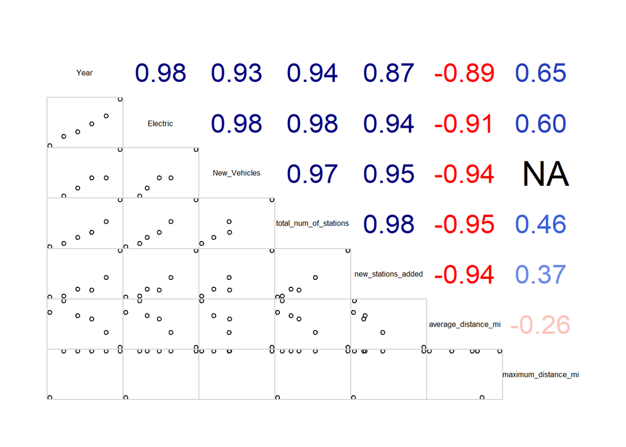

```r
# Following plot was commented out because it is replaced later with a bar chart displaying the same data, and
# this call to the TX_analysis_with_registrations data frame is altered later when I factor the Year column.
# I wanted to still keep it in to demonstrate ggplot2 proficiency.

# percentage_line_plot <- ggplot(data=TX_analysis_with_registrations) +
#   geom_line(mapping=aes(x=Year, y=registrations_percent_change), color="skyblue", linewidth=1.5) +
#   geom_line(mapping=aes(x=Year, y=stations_percent_change), color="yellow", linewidth=1.5) +
#   geom_line(mapping=aes(x=Year, y=distance_percent_change), color="pink", linewidth=1.5) +
#   geom_hline(mapping=aes(yintercept=0), color="black") +
#   labs(y="Percent Change") +
#   annotate(geom="richtext",x=2016.5,y=31.5,label="<b>Charging stations</b>", color="goldenrod") +
#   annotate(geom="richtext",x=2016.5,y=36,label="<b>EV registrations</b>", color="darkblue") +
#   annotate(geom="richtext",x=2016.5,y=5.5,label="<b>Average distance</b><br><b>between stations</b>", color="darkred")
# percentage_line_plot

correlation_data <- TX_analysis_with_registrations %>%
  select(!c("State","registrations_percent_change","stations_percent_change","distance_percent_change"))

correlation_data[1,2]=0
correlation_data$Year <- as.double(correlation_data$Year)
correlation_data <- as.matrix(correlation_data)

correlation_plot <- corrgram(correlation_data, lower.panel=panel.pts, upper.panel=panel.cor)
```

From the correlation graph, we see strong correlations between some key metrics. Disregarding the ones that are to be expected, such as the number of new stations and the total number of stations, we can see a very strong correlation (>95%) between the number of EV registrations and time, EV registrations and the total number of stations, and, very importantly, the total number of stations and the average distance between them. We will explore these more closely next.

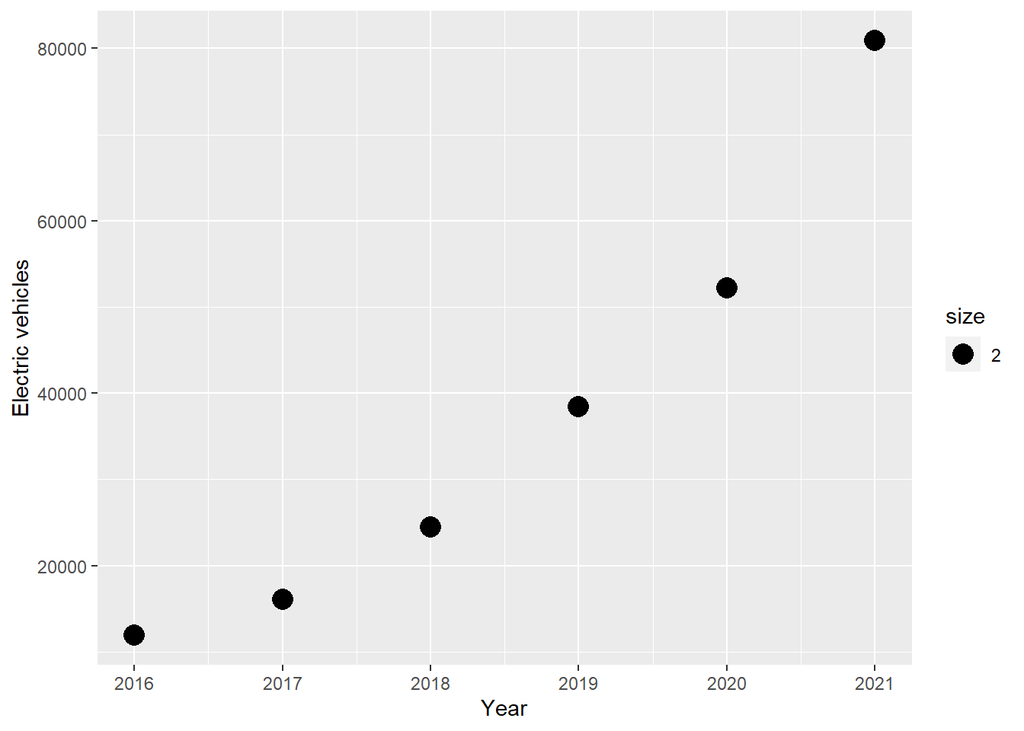

```r
registrations_vs_year_scatter <- ggplot(data=TX_analysis_with_registrations) +
  geom_point(mapping=aes(x=Year, y=Electric, size=2)) +
  labs(y="Electric vehicles")
registrations_vs_year_scatter
```

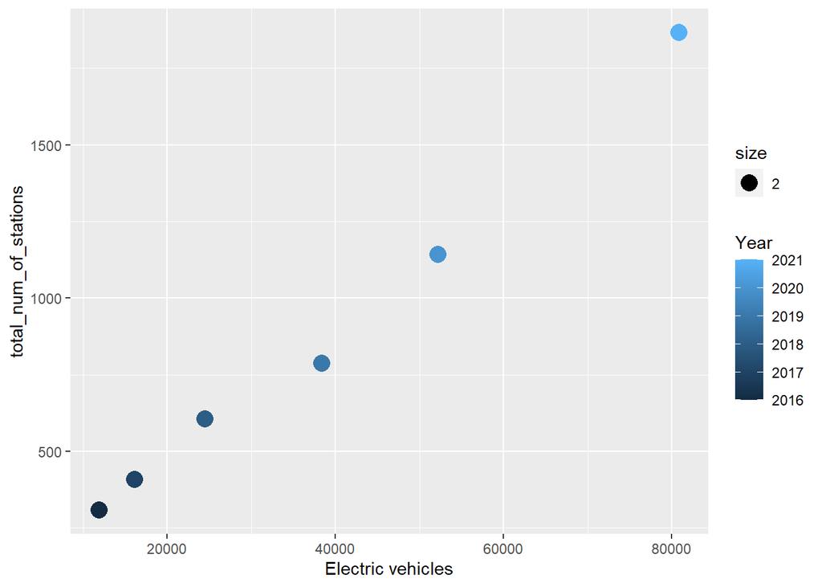

```r
stations_vs_registrations_scatter <- ggplot(data=TX_analysis_with_registrations) +
  geom_point(mapping=aes(x=Electric, y=total_num_of_stations, color=Year, size=2)) +
  labs(x="Electric vehicles")
stations_vs_registrations_scatter
```

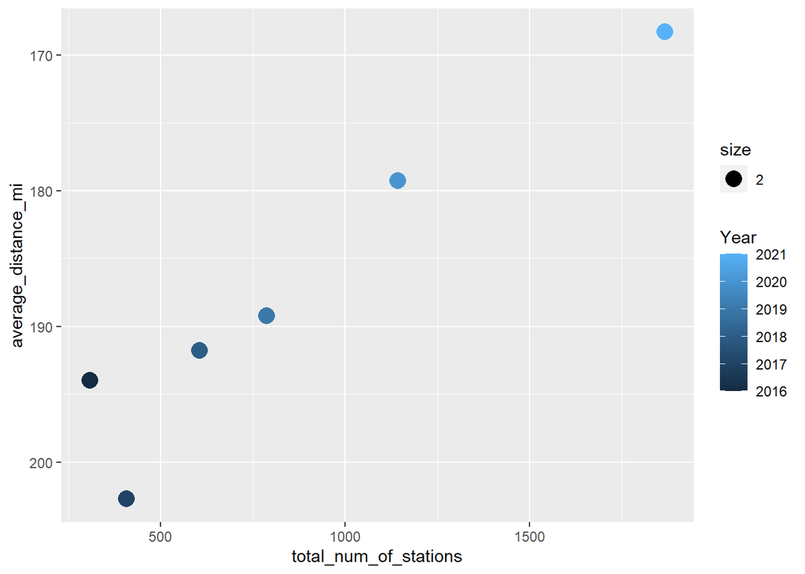

```r
stations_vs_distance_scatter <- ggplot(data=TX_analysis_with_registrations) +
  geom_point(mapping=aes(x=total_num_of_stations, y=average_distance_mi, color=Year, size=2)) +
  scale_y_reverse()
stations_vs_distance_scatter
```

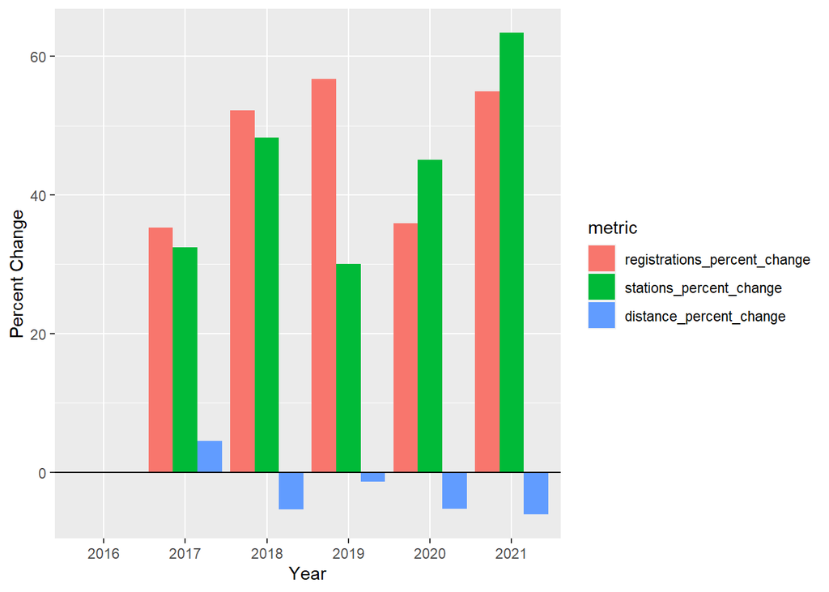

```r
TX_analysis_with_registrations$Year <- factor(TX_analysis_with_registrations$Year)

column_data <- TX_analysis_with_registrations %>%
  select("Year","registrations_percent_change","stations_percent_change","distance_percent_change")

column_data_long <- gather(column_data, key="metric", value="percentage", registrations_percent_change:distance_percent_change, factor_key=TRUE)

percentage_column_plot <- ggplot(data=column_data_long) +
  geom_col(mapping=aes(x=Year, y=percentage, group=metric, fill=metric), position="dodge") +
  labs(y="Percent Change") +
  geom_hline(mapping=aes(yintercept=0), color="black")
percentage_column_plot
```

Starting with the first chart, we clearly see that EV registrations are increasing over time. From this, we can infer, at the very least, that public interest is staying the same or increasing in regards to owning an electric vehicle. To get a better understanding, a follow-up step would be to calculate the market share of EVs for these years.

The next chart then shows that the total number of EV charging stations is increasing to meet the demand of more EVs, almost perfectly linearly.

Next, we see that in this time period, there is an inverse linear relationship between the total number of stations and the average distance between them, which is a good sign! This shows that EV range is being taken into account when new charging station locations are selected, with the ultimate goal of driving the distance between stations down.

Finally, the last chart raises quite a few important questions. Focusing on the relationship between registration percent change (RPC) and station percent change (SPC), we see a larger percentage increase for EV registrations than total number of stations from 2016 to 2019, with 2019 having the lowest SPC of all the years considered. This could have had an effect on the following year’s RPC, which also took a dip, but further research would be required. Following 2019, we see the trend flip, with SPC being higher than RPC for 2020 and 2021. This could potentially become a problem if the state becomes over saturated with charging stations and the amount of EVs does not warrant them. Something to keep an eye on in the following years. Now looking at the relationship between SPC and the average distance percent change (DPC), we see the same inverse relationship as we did in the scatter plot, except for 2017. I interpret this as a push to build stations in less serviced areas, farther from larger cities where a majority of stations are built. With Texas as big as it is, if stations were built into smaller communities, it would inevitably drive the average distance up. Looking at the geographical data on the Tableau visualization, this seems to be exactly the case. Multiple stations are constructed along highways where there previously weren’t any stations, as well as in more remote areas of Texas. More research could be done on state EV initiatives in 2016 and 2017 to get a better understanding of the circumstances that led to this increase in average distance.

I don’t believe we will get access to EV registration data in Texas prior to 2016, at least from the source I initially used. However, as time goes on, we will gain access to more years of data. As a matter of fact, at the time of this edit, data for 2022 is available on the website! I am not including it mainly because I did not plan for this project to be updated ad infinitum.

## 2011-2023: The full data set

For this section, EV registrations in Texas will be omitted and the focus will be on the station data. The data set includes stations from 2009 to 2023, however, in the final code chunk of this section, I omit the years 2009 and 2010 from the statistical analysis due to there being only two stations in the entire state during those years. The SPC in 2011 would have been 3,000%, and I did not want that to skew the graphical results.

```r
percent_change_total_stations <- double()
percent_change_new_stations <- double()
percent_change_distance <- double()

for(i in (2:nrow(TX_analysis))){
  dummy1 <- round(TX_analysis[i, "total_num_of_stations"]/TX_analysis[(i-1), "total_num_of_stations"], 4)
  dummy2 <- round(TX_analysis[i, "new_stations_added"]/TX_analysis[(i-1), "new_stations_added"], 4)
  dummy3 <- round(TX_analysis[i, "average_distance_mi"]/TX_analysis[(i-1), "average_distance_mi"], 4)

  percent_change_total_stations <- c(percent_change_total_stations, (dummy1-1)*100)
  percent_change_new_stations <- c(percent_change_new_stations, (dummy2-1)*100)
  percent_change_distance <- c(percent_change_distance, (dummy3-1)*100)
}

percent_change_total_stations <- c(NA, percent_change_total_stations)
percent_change_new_stations <- c(NA, percent_change_new_stations)
percent_change_distance <- c(NA, percent_change_distance)

TX_analysis <- TX_analysis %>%
  mutate(total_stations_percent_change=percent_change_total_stations, new_stations_percent_change=percent_change_new_stations, average_distance_percent_change=percent_change_distance)

distance_corrgram <- corrgram(select(TX_analysis, "year":"maximum_distance_mi"), lower.panel=panel.cor, upper.panel=panel.pts)
```

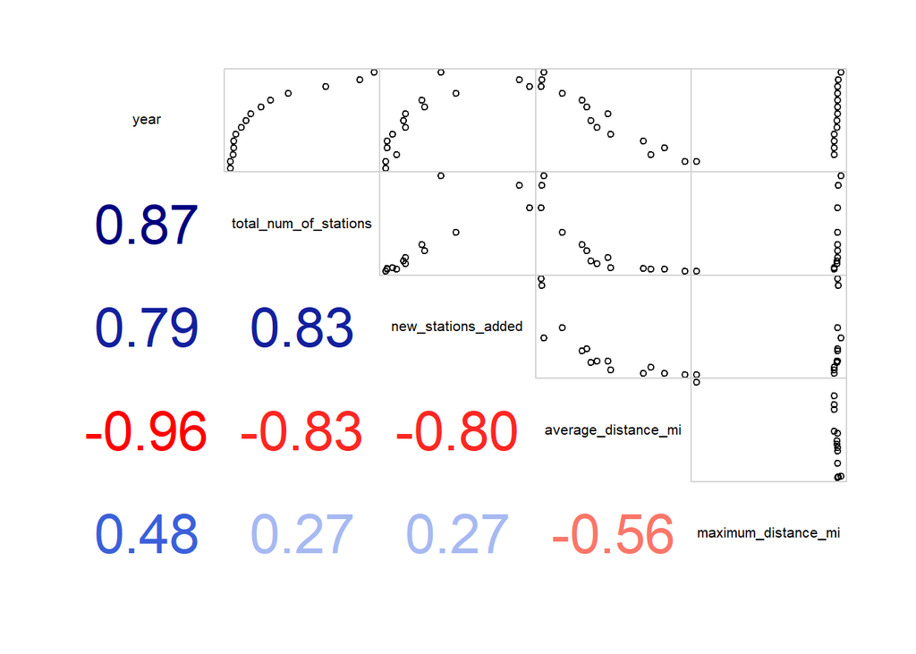

Looking at our correlation graph for the full station data set, we see generally weaker correlations between the same variables than we saw in the 2016-2021. We will focus on the number of stations over time and the number of stations and average distance.

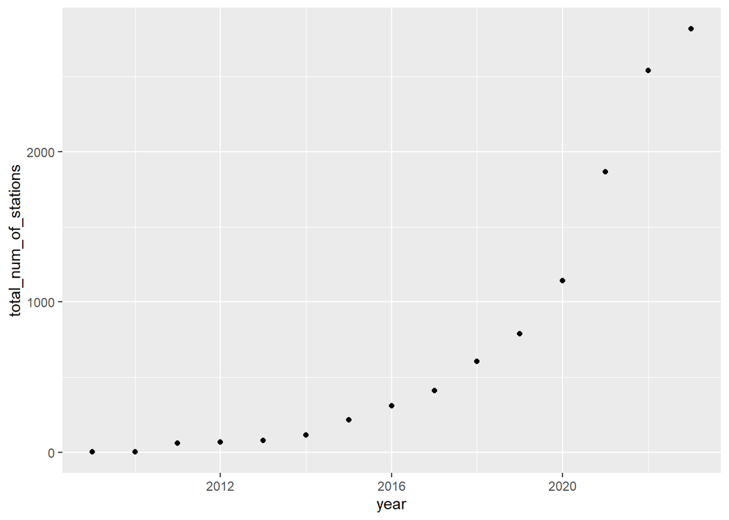

```r
total_stations_vs_time <- ggplot(data=TX_analysis) +
  geom_point(mapping=aes(x=year, y=total_num_of_stations))
total_stations_vs_time
```

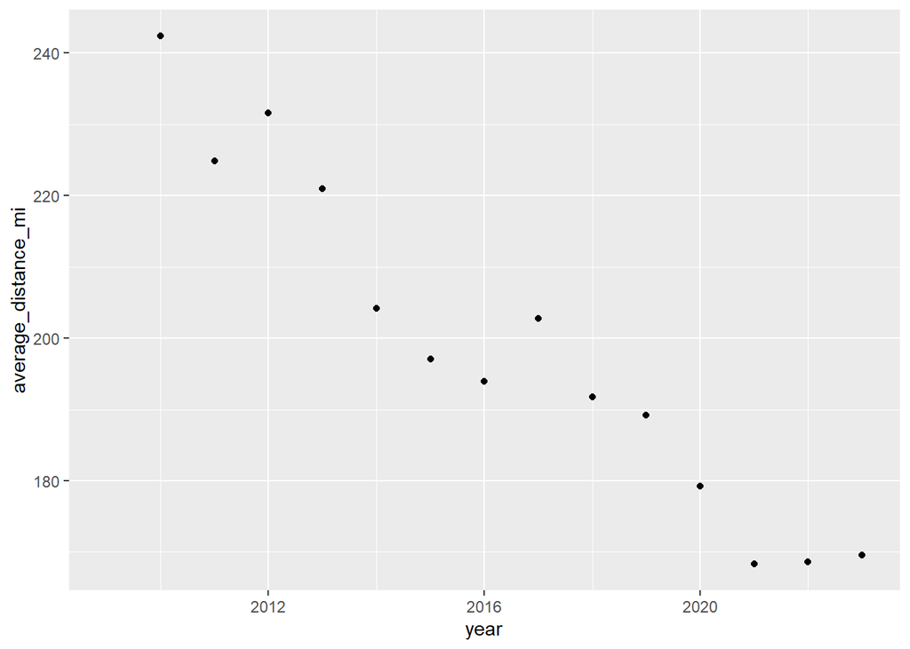

```r
avg_distance_vs_time <- ggplot(data=TX_analysis) +
  geom_point(mapping=aes(x=year, y=average_distance_mi))
avg_distance_vs_time
```

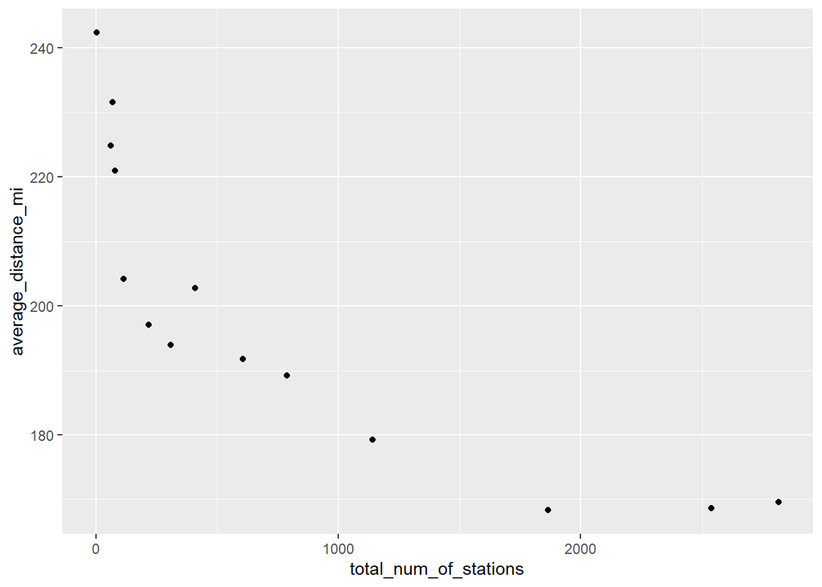

```r
avg_distance_vs_total_stations <- ggplot(data=TX_analysis) +
  geom_point(mapping=aes(x=total_num_of_stations, y=average_distance_mi))
avg_distance_vs_total_stations
```

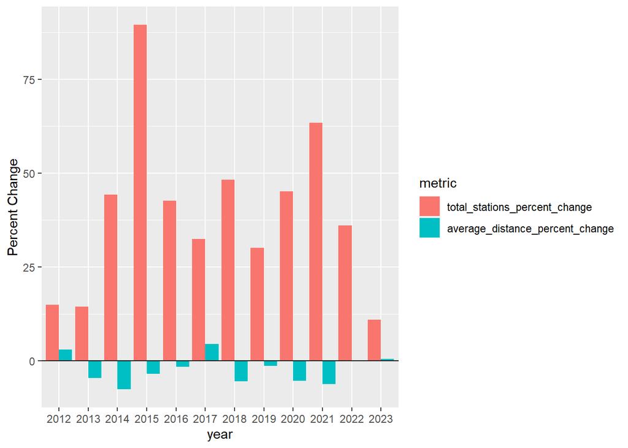

```r
column_data <- TX_analysis %>%
  select("year", "total_stations_percent_change","average_distance_percent_change") %>%
  filter(year>2011)

column_data$year <- factor(column_data$year)

column_data_long <- gather(column_data, key="metric", value="percentage", total_stations_percent_change:average_distance_percent_change, factor_key=TRUE)

distance_percentages_column <- ggplot(column_data_long) +
  geom_col(mapping=aes(x=year, y=percentage, group=metric, fill=metric), position="dodge") +
  labs(y="Percent Change") +
  geom_hline(yintercept=0, color="black")
distance_percentages_column
```

Looking at our first graph, we see the growth of total number of stations over time (with SPC on detailed on the final graph). One interesting thing to note, the final data point suggest a flattening of the curve, which could indicate that we are reaching a point where we add fewer stations each successive year. As time goes on, the solution to charging station access will be less about the *number* of stations and more about how *spread out* they are. Which leads us to our next graph.

While the year itself doesn’t actually influence the average distance, viewing the relationship is still valuable. We do see a downward trend for the average distance between stations as time goes on. I believe this should be the metric that is the main focus when selecting locations for new charging stations.

Looking at our final two graphs, there is one thing I wanted to point out. The last two years of data, we see little change to the average distance between stations, which can be interpreted as the new stations being built very close in proximity to previously built stations, Which seems counter intuitive and not very productive. However, stated at the beginning of this project, I considered all charging stations equal in terms of charging ports offered, but this is not the case. EVs have a variety of fast charging connections and not all connections are supported at every station. Another explanation is the specific company that builds and maintains the specific charging stations. Companies have every incentive to build stations in high volume areas where they previously did not have a station, regardless of if this keeps the state’s average distance between stations down.

```r
# for(i_year in (2011:2023)){
#   dummy_name <- paste("distances_", i_year, sep="")
#   dummy_df <- read_csv(paste("D:\\GoogleDataAnalyticsCertificate\\8.CapstoneProject\\by_state_analysis\\texas_focus\\distances_", i_year, ".csv", sep=""))
#
#   dummy_df <- dummy_df %>%
#     mutate(year=i_year) %>%
#     mutate(distance=get(paste("TX_",i_year,"_distances", sep=""))) %>%
#     select("year","distance") %>%
#     mutate(old_or_new=NA)
#
#   if(i_year==2011){
#     dummy_df <- dummy_df %>%
#       mutate(old_or_new="new")
#
#     old_count=nrow(dummy_df)
#   } else{
#     for(i in (1:old_count)){
#       dummy_df[i, "old_or_new"] = "old"
#     }
#     for(i in((old_count+1):nrow(dummy_df))){
#       dummy_df[i, "old_or_new"] = "new"
#     }
#     old_count <- nrow(dummy_df)
#   }
#
#   assign(dummy_name, dummy_df)
# }
```

The above code chunk was made to be able to differentiate between which distance calculations had been added by new stations per year. This was so when I transferred to Tableau, I could make a color coded histogram for distances. This took two days to compute! I was very surprised. I considered changing the `old_or_new` column to a boolean in the hopes that it would take less memory to store/update, but I was already a day into running the chunk and decided to just wait for my results. This code has been commented out so it won’t run on upload to Github.

And don’t forget to check out the companion Tableau visualization I made for this project! It includes geological locations over a map of Texas that distinguishes the year each station was made available as well as a histogram of the distance calculations made in these scripts.

https://public.tableau.com/app/profile/torin.rose/viz/TexasElectricVehicleChargingStationDistanceAnalysis/ElectricVehicleChargingStationsTexas

# Final thoughts

If you made it this far, thank you for taking the time to review my project! I am publishing this as a webpage through Github in my efforts to start my career in data analytics. When I started this project, I quickly realized that I had undertaken a much bigger task than I initially thought, and if I had all of the time in the world, I would like to continue the analysis for Texas and perhaps for other states as well.

For any questions, comments, or concerns, feel free to contact me at torinrose1@gmail.com